# Quant Methods - Time Series 4 - Missing values and interpolation

Last class we filled in the time missing from the Miss R discharge record for Hurricane Ida

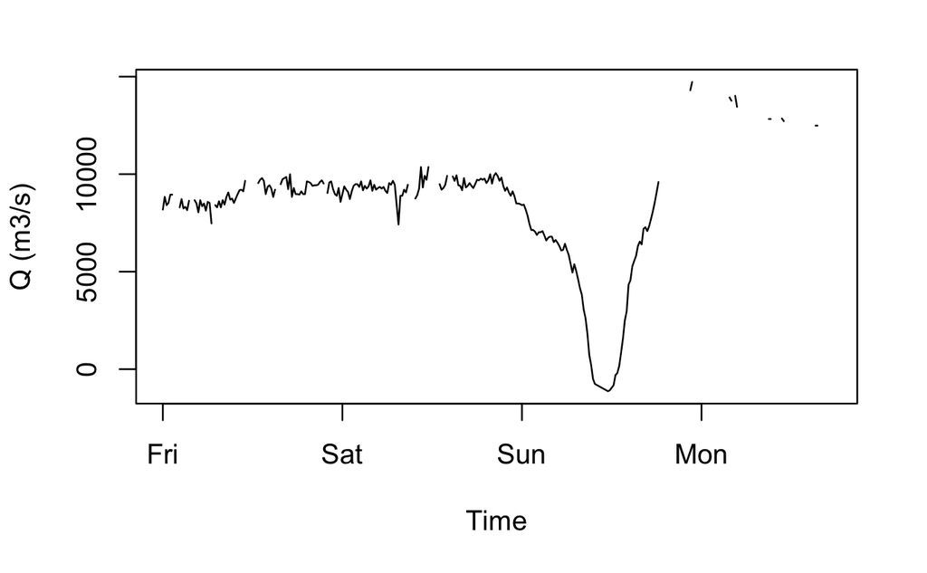

```r
#ReadUSGS_V2_QM.R
library(dplyr)
library(lubridate)

Qdf = read.csv("USGSMissRDischargeAug2021.csv")
Qdf$DT = force_tz(mdy_hm(Qdf$DateTime), tzone="US/Central") #assign Central Time to DateTime
Qdf$Qm3s = Qdf$Qcfs * (0.3048^3) #convert to m3/s

#create full date vector
t1 = Qdf$DT[1]
t2 = Qdf$DT[length(Qdf$DT)]
tfull = seq.POSIXt(t1, t2, by = "15 min")
QFdf = data.frame(tfull) #make a data frame out of full date vector

#merge Qdf data frame with full date data frame using left_join() in dplyr package
#column names on merged variable (DT in this case) must be identical
colnames(QFdf) = c("DT")
QNdf = left_join(QFdf, Qdf, by="DT")

plot(QNdf$DT, QNdf$Qm3s, type="l", ylab="Q (m3/s)", xlab="Time")
```

As we noticed before there are missing values - some scattered through the dataset, some larger gaps near end.

Several questions to consider. - 1) Pros/cons of filling in missing dates? a full set of times is necessary for some common types of analysis, including correlation and smoothing comparisons between datasets requires matching times, which is easiest if they use same time base

- 2. Pros/cons of filling in missing values?

Missing data values

The simplest way to deal with missing data values is some form of interpolation, provided that there are only a few sporadic missing values and the parameter being interpolated varies relatively smoothly. The function in R for linear interpolation is approx(). We’ll examine this function and some considerations regarding its use through the code interpolation_sintim.R available on Collab under Resources/ClassCodes

**Interpolation**

This follows the examples in the code interpolation_sintms.R.

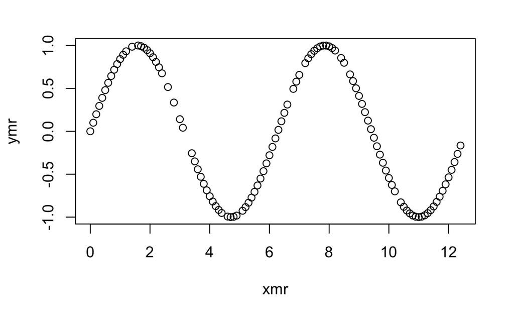

```r
x = seq(0,4*pi,0.1)
y = sin(x)

#generate 15 random integers between 1 and length of y
r = round(runif(15,max=length(x)))
ymr = y[-r] #remove values from row numbers = r
xmr = x[-r]
ymrna = y
xmrna = x
ymrna[r] = NA #replace values with NA in row numbers = r

plot(xmr, ymr)
```

Note [xmr,ymr] removed the “missing values” while [xmrna, ymrna] replaced the missing values with NAs.

The approx() function can be used to fill in the missing values using linear interpolation. The arguments for approx are the x and y values of data requiring interpolation and the x values that you want to have values for after interpolation. The output is a list with columns if interpolated x and y.

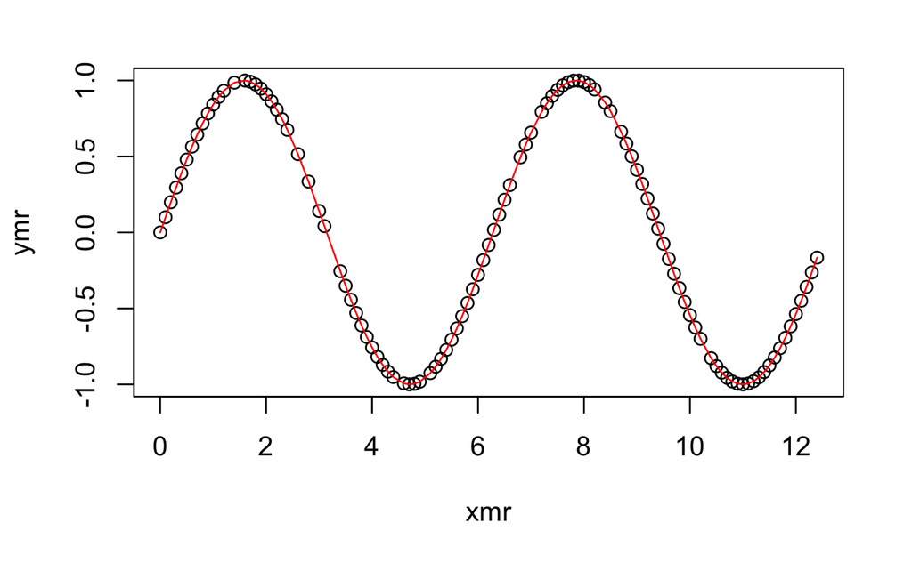

```r
#approx() uses linear interpolaiton to fill in missing values
#output is list with x and y.
yint = approx(xmr,ymr,x)  #missing values added
yintna = approx(xmrna,ymrna,x)  #NA values replaced
#interpolated values are in yint$y or yintna$y

plot(xmr,ymr)
lines(yint$x,yint$y,type="l", col="red")
```

```r
#plot(xmrna,ymrna)
#lines(yintna$x,yintna$y,type="l", col="red")
```

Interpolation looks good here.

Take out lots more points.

```r
r2 = round(runif(100,max=length(x)))
ymrna2 = y
ymrna2[r2] = NA
xmrna2 = x
plot(xmrna2,ymrna2)

yint2 = approx(xmrna2,ymrna2,x)
lines(yint2$x,yint2$y,type="l", col="red")
```

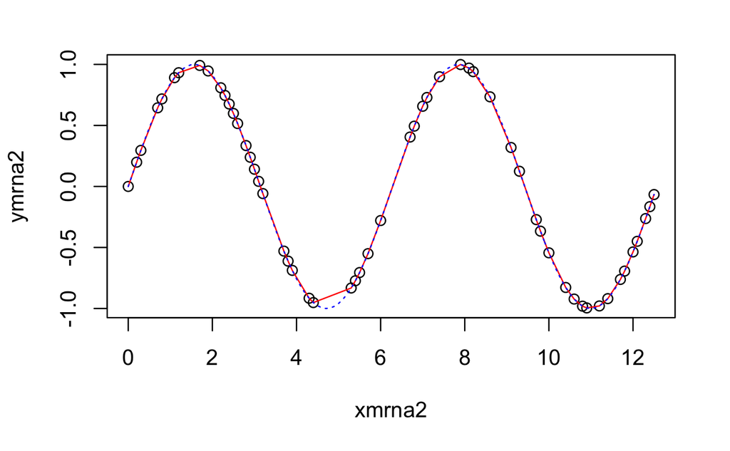

```r
lines(x,y,type="l",lty=3,col="blue")
```

Still doesn’t look too bad unless there is a gap, but the different between the interpolated value and the original value is larger than the case of 15 missing values.

What about a longer gap?

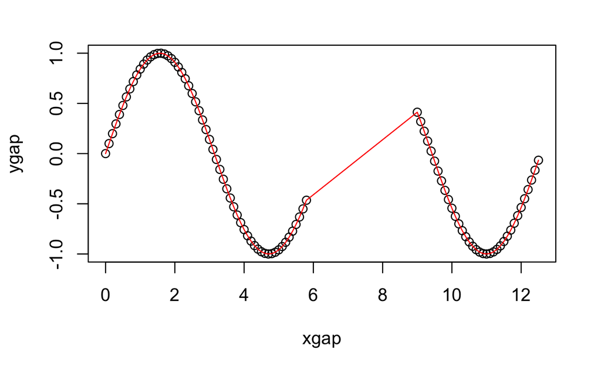

```r
ygap = y; xgap = x
ygap[(60:90)] = NA
plot(xgap,ygap)

yint3 = approx(xgap,ygap,x)
lines(yint3$x,yint3$y,type="l", col="red")
```

Better approach for case like this?

Splines offer an alternative. Splines take into account the curvature of the function.

```r
yint3s = spline(xgap,ygap,method="fmm",xout=x)
plot(xgap,ygap)
lines(yint3$x,yint3s$y,type="l",col="green")
```

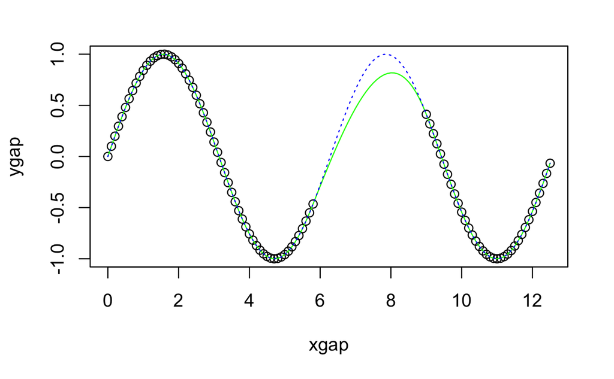

```r
lines(x,y,type="l",lty=3,col="blue")
```

Closer in shape, but still a limit to how much of original function can be reconstructed.